# Cancer Clinical Trials 2020-2024 Report

by Gen

2026-10-15

Cancer encompasses a heterogeneous group of diseases characterised by the uncontrolled proliferation of abnormal cells, often arising from genetic alterations that disrupt normal cellular regulatory mechanisms. Malignant cells can invade surrounding tissues and spread to distant anatomical sites through metastasis (National Cancer Institute, 2026). Cancer remains a significant global health challenge, driving continuous research into the development and evaluation of effective treatment interventions. Clinical trials play a fundamental role in this process by investigating the safety, efficacy, and clinical applications of pharmaceutical drugs, medical devices, and procedural interventions. Clinical research involves different stages of investigations. Phase I trials generally focus on safety, tolerability, and dosage. Phase II trials provide further evidence of safety, and preliminary efficacy. Phase III trials commonly evaluate treatment effectiveness, and safety in larger patient populations. Phase IV trials generally involve post marketing studies of approved cancer interventions. Clinical trial phase classifications are primarily associated with drug and biological product development, and may not be directly required or applicable to observational, device, or procedural clinical studies.

The objectives of this study was to investigate the distribution of cancer clinical trials conducted between 2020 and 2024, with particular attention to intervention type, and clinical trial phase. The analysis seeked to determine whether pharmaceutical drug interventions were more frequently represented than device and procedural interventions, and whether intervention type was associated with classification in later clinical trial phases, particularly Phase III and Phase IV.

The Cancer Clinical Trials 2020–2024 dataset was obtained from Kaggle and contains 10,000 clinical trial records, 14 variables and all completed cancer trial studies. The key features selected for this analysis include nct_id, study_type, phase, conditions, interventions, intervention_types, enrollment, start_date and completion_date. These variables were selected to evaluate clinical trial characteristics, intervention classifications, and clinical development phases, as well as to explore patterns and relationships between participant enrollment, and trial duration. The study applied descriptive statistics, exploratory data analysis, statistical binomial hypothesis testing, and logistic regression modelling.

**Descriptive Data Analysis**

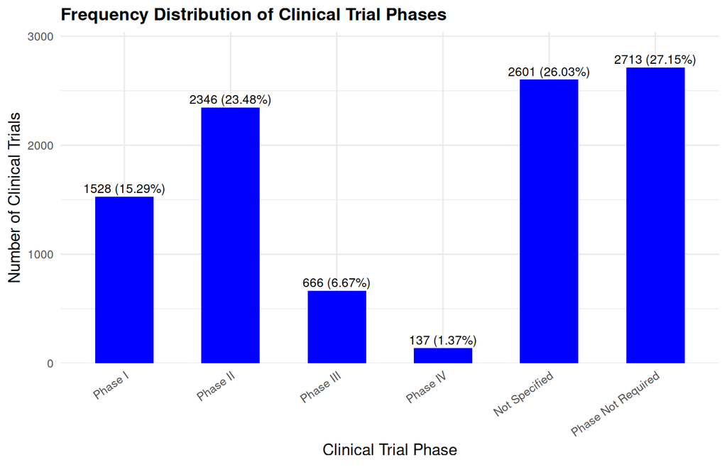

Figure 1.0 Bar Graph of Frequency Distribution for Standardised Phases in Cancer Clinical Trials 2020-2024 (N=9991). 9 zero-day duration observations were excluded from the original 10,000 records.

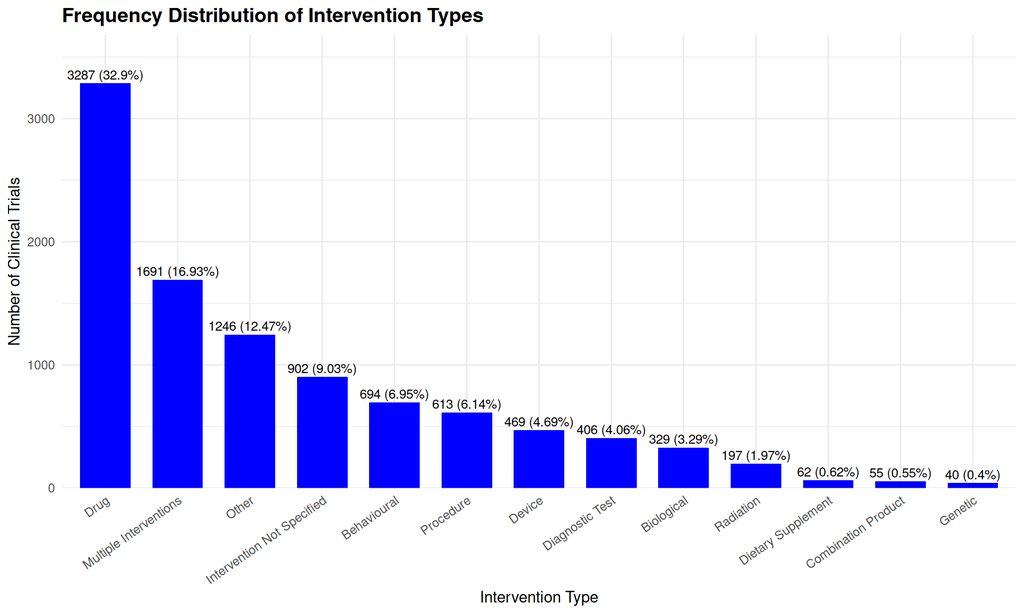

Figure 2.0 Bar Graph of Frequency Distribution for Standardised Intervention Types in Cancer Clinical Trials 2020-2024 (N=9991). 9 zero-day duration observations were excluded from the original 10,000 records.

Clinical trial enrollment distribution varied considerably across the dataset, ranging from a minimum of 1 participant to a maximum of 36,580,288 participants. The mean enrollment was 9260.02 participants, which was substantially higher than the median 66 participants, and mode 30 participants. The interquartile range (IQR) was 163 participants, indicating considerable variability within the middle 50% of observations. The enrollment variable was evaluated for potential outliers (13.1%, n=1305).

Measures of Central Tendency and Dispersion for Clinical Trial Enrolment

| Statistical Measure | Enrolment |
| --- | --- |
| Mean | 9260.02 |
| Median | 66.00 |
| Mode | 30.00 |
| Minimum | 1.00 |
| Maximum | 36580288.00 |
| SD | 408520.59 |
| Q1 | 30.00 |
| Q3 | 193.00 |
| IQR | 163.00 |

Figure 3.0 Table of Central Tendency and Dispersion Measurements for Enrollment in Cancer Clinical Trials 2020-2024 (N=9991). 9 zero-day duration observations were excluded from the original 10,000 records.

The clinical trial duration’s distributions revealed considerable variability. The maximum participant duration was 15705 days and the minimum was 3 days. The mean trial duration was 1659.31 days, exceeding the median of 1294 days, and mode of 730 days. The interquartile range (IQR) was 1525.50 days, indicating a large variation in clinical trial durations among the middle 50% of observations. The clinical durations were evaluated for potential outliers (4.92%, n=492).

Measures of Central Tendency and Dispersion for Clinical Trial Duration

| Statistical Measure | Duration (Days) |
| --- | --- |
| Mean | 1659.31 |
| Median | 1294.00 |
| Mode | 730.00 |
| Minimum | 3.00 |
| Maximum | 15705.00 |
| SD | 1450.07 |
| Q1 | 665.50 |
| Q3 | 2191.00 |
| IQR | 1525.50 |

Figure 4.0 Table of Central Tendency and Dispersion Measurements for Duration (Days) in Cancer Clinical Trials 2020-2024 (N=9991). 9 zero-day duration observations were excluded from the original 10,000 records.

**Exploratory Data Analysis**

Exploratory Data Analysis was used to investigate any potential outliers in enrollment and duration. Outliers in enrolment were represented by positive skewing (mean = 9260.02, median = 66), indicating there were large clinical trial enrollments. Enrollment distribution was differentiated by study type. There were 7391 clinical trials enrolled as interventional, with mean 288.28, median 53, IQR 98, and outliers 910 (12.31%). There were 2600 clinical trials enrolled as observational, with mean 34763.93, median 170, IQR 467.75, and outliers 363 (13.96%). However, these outliers did not impact the objectives of the study. The enrollment outliers were not directly included in the statistical modelling of binomial hypothesis testing, Pearson Chi-square testing, or binary logistic regression modelling.

Enrollment Distribution and Potential Outliers by Clinical Trial Study Type

| Study Type | Total Trials | Mean | Median | Q1 | Q3 | IQR | Upper Bound | Outliers | Outliers (%) |
| --- | --- | --- | --- | --- | --- | --- | --- | --- | --- |
| INTERVENTIONAL | 7391 | 288.28 | 53 | 25 | 123.00 | 98.00 | 270.00 | 910 | 12.31 |
| OBSERVATIONAL | 2600 | 34763.93 | 170 | 60 | 527.75 | 467.75 | 1229.38 | 363 | 13.96 |

Figure 5.0 Enrollment Distribution of Potential Outliers by Study Type (n=9991). 9 zero-day duration observations were excluded from the original 10,000 records.

Outliers in duration were represented by positive skewing (mean = 1659.31, median = 1294), indicating there were clinical trials with longer duration days. Outlier’s analysis using Tukey’s fences (1.5 × IQR method) identified no potential lower outliers in duration, while 492 clinical trials (4.92%) were classified as potential upper threshold outliers. These findings indicate that extreme duration values were concentrated in the upper tail of the distribution. Outliers in duration were not directly included in the statistical modelling of binomial hypothesis testing, Pearson Chi-square testing, or binary logistic regression modelling.

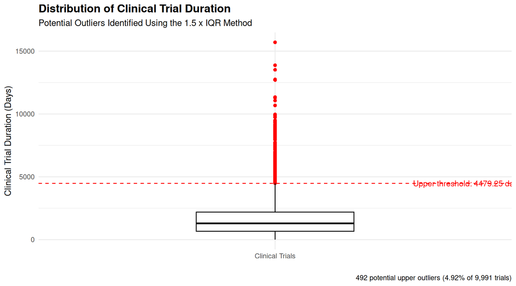

Figure 6.0 Boxplot of Duration Distribution of Potential Outliers (n=9991). 9 zero-day duration observations were excluded from the original 10,000 records.

**Statistical One-Sided Binomial Hypothesis Test**

A statistical one-sided binomial test was conducted to investigate whether Drug interventions were more frequently represented than Device and Procedure interventions combined. Out of the 4369 selected clinical trials, 3287 (75.23%) were classified as Drug interventions, compared with 1082 (24.77%) classified as combined Device or Procedure interventions.

The observed Drug proportion was 0.7523, with a one-sided 95% confidence interval lower bound of 0.7414. The test demonstrated a statistically significant result (p < 0.001), indicating that the observed proportion of Drug interventions was significantly greater than the hypothesised proportion of 0.50. Therefore, the null hypothesis was rejected, providing strong statistical evidence that Drug interventions were more frequently represented than Device and Procedure interventions combined within the clinical trials dataset.

One-Sided Binomial Hypothesis Test: Drug vs Device and Procedure Interventions

| Statistical Measure | Result |
| --- | --- |
| Statistical Test | One-sided Exact Binomial Test |
| Drug Interventions | 3,287 |
| Device Interventions | 469 |
| Procedure Interventions | 613 |
| Device + Procedure Interventions | 1,082 |
| Total Included Trials | 4,369 |
| Drug Proportion (%) | 75.23% |
| Device + Procedure Proportion (%) | 24.77% |
| Null Hypothesis Proportion | 50% |
| P-Value | <0.001 |
| 95% Confidence Interval Lower Bound (%) | 74.14% |
| Significance Level | 0.05 |
| Hypothesis Decision | Reject Null Hypothesis |

Figure 7.0 Statistical One-Sided Binomial Hypothesis Test

**Pearson Chi-Square Test of Independence**

Pearson Chi-square Test of Independence and Cramér’s V

| Statistical Measure | Result |
| --- | --- |
| Pearson Chi-square Statistic | 27.41 |
| Degrees of Freedom | 6 |
| Total Observations | 2962 |
| P-Value | <0.001 |
| Cramér’s V | 0.068 |
| Minimum Expected Frequency | 0.81 |
| Expected Cells Below 5 (%) | 33.33 |
| Hypothesis Decision | Reject Null Hypothesis |

Figure 8.0 Pearson Chi-Square Test of Independence and Cramer’s V

**Binary Logistic Regression Modelling**

Binary logistic regression was conducted to investigate whether intervention type was associated with the odds of a clinical trial being classified as Phase III or Phase IV, compared with Phase I or Phase II. The analysis included 2962 clinical trials of Phases I–IV, using Drug interventions as the reference category.

Overall, the analysis identified statistically significant differences in later-phase classification between Procedure and Drug interventions, while the estimated difference between Device and Drug interventions did not reach statistical significance.

Logistic Regression: Odds Ratios and Statistical Significance

| Intervention | Odds Ratio | 95% Confidence Interval | P-Value | Significant? | Interpretation |
| --- | --- | --- | --- | --- | --- |
| Device vs Drug | 2.34 | 0.89 - 5.51 | 0.0624455 | No | Not statistically significant |
| Procedure vs Drug | 4.13 | 2.15 - 7.81 | 0.0000143 | Yes | Statistically significant |

Figure 9.0 Logistic Regression Model for Intervention Types and Phases

**Conclusion**

The objective of this study was to investigate the distribution of cancer clinical trials conducted between 2020 and 2024, with particular emphasis on intervention type and clinical trial phase classification. The findings provided strong statistical evidence of an association between intervention type and clinical trial phase classification, indicating that the distribution of clinical phases differed significantly across Drug, Device and Procedure interventions. The analysis provided statistically significant evidence that Procedure interventions had higher odds of being classified in later clinical trial phases (Phases III and IV) compared with Drug interventions (OR = 4.13, p < 0.001). Although Device interventions also demonstrated higher estimated odds of later-phase classification (OR = 2.34), this association was not statistically significant (p = 0.0624).

Furthermore, while Drug interventions were significantly more prevalent than Device and Procedure interventions combined in the overall Cancer Clinical Trials 2020-2024 dataset, the analysis did not establish that Drug interventions were more prevalent in the later clinical trial phases (Phases III and IV). Overall, these findings highlight the importance of distinguishing between statistical association and evidence of clinical trial progression. Although intervention type was significantly associated with phase classification, this association does not necessarily indicate that Drug interventions are more likely to advance into later stages of clinical development.

**References**

National Cancer Institute. (2026.). What is cancer? U.S. Department of Health and Human Services. https://www.cancer.gov/about-cancer/understanding/what-is-cancer